# Evaluation of Machine Learning Methods for Network Intrusion Detection

## Data Preprocessing

### Set up

```python
# set up
import pandas as pd
import matplotlib.pyplot as plt
import seaborn as sns
import numpy as np
from scipy.stats import norm
from sklearn.preprocessing import StandardScaler
from sklearn.model_selection import train_test_split
from scipy import stats
import warnings
warnings.filterwarnings('ignore')
%matplotlib inline
```

### Read in data

```python
# create list to hold column names
col_names = ("date","duration","proto","src_ip","src_port","dst_ip","dst_port",
             "packets","bytes","flows","flags","tos","label","attack_type","attack_id","attack_descr")
# read in data
df1 = pd.read_csv("/Users/mp_ssd/Documents/Network_Intrusion/data/CIDDS-001/traffic/ExternalServer/CIDDS-001-external-week1.csv",
                 dtype={'Duration': float,
                        'Proto':str,
                        'Src IP Addr':str,
                        'Src Pt': int,
                        'Dst IP Addr':str,
                        'Dst Pt':float,
                        'Packets':float,
                        'Bytes':str,
                        'Flags':str,
                        'class':str,
                        'attackType':str,
                        'attackID':str,
                        'attackDescription':str},
                  names = col_names,
                  header=0)

df2 = pd.read_csv("/Users/mp_ssd/Documents/Network_Intrusion/data/CIDDS-001/traffic/ExternalServer/CIDDS-001-external-week2.csv",
                 dtype={'Duration': float,
                        'Proto':str,
                        'Src IP Addr':str,
                        'Src Pt': int,
                        'Dst IP Addr':str,
                        'Dst Pt':float,
                        'Packets':float,
                        'Bytes':str,
                        'Flags':str,
                        'class':str,
                        'attackType':str,
                        'attackID':str,
                        'attackDescription':str},
                  names = col_names,
                  header=0)

df3 = pd.read_csv("/Users/mp_ssd/Documents/Network_Intrusion/data/CIDDS-001/traffic/ExternalServer/CIDDS-001-external-week3.csv",
                 dtype={'Duration': float,
                        'Proto':str,
                        'Src IP Addr':str,
                        'Src Pt': int,
                        'Dst IP Addr':str,
                        'Dst Pt':float,
                        'Packets':float,
                        'Bytes':str,
                        'Flags':str,
                        'class':str,
                        'attackType':str,
                        'attackID':str,
                        'attackDescription':str},
                  names = col_names,
                  header=0)

df4 = pd.read_csv("/Users/mp_ssd/Documents/Network_Intrusion/data/CIDDS-001/traffic/ExternalServer/CIDDS-001-external-week4.csv",
                 dtype={'Duration': float,
                        'Proto':str,
                        'Src IP Addr':str,
                        'Src Pt': int,
                        'Dst IP Addr':str,
                        'Dst Pt':float,
                        'Packets':float,
                        'Bytes':str,
                        'Flags':str,
                        'class':str,
                        'attackType':str,
                        'attackID':str,
                        'attackDescription':str},
                  names = col_names,
                  header=0)

# set dtype for dates
df1['date'] = pd.to_datetime(df1['date'])
df2['date'] = pd.to_datetime(df2['date'])
df3['date'] = pd.to_datetime(df3['date'])
df4['date'] = pd.to_datetime(df4['date'])
# append each to df in to one
frames = [df1, df2, df3, df4]
df = pd.concat(frames)
# remove variables that are inconsequential to our modeling
del df['attack_id'],df['attack_descr'],df['tos'],df['flows']
```

#### Check for missing values and print proportion each variable contains.

```python
# check for any missing values
#df.isnull().values.any()
# if needed, find the percentage of missing values in each variable
df.isnull().sum()/len(df)*100
# # drop rows with null values if neccesary
# df = df.dropna(axis=0)
```

```
date           0.0
duration       0.0
proto          0.0
src_ip         0.0
src_port       0.0
dst_ip         0.0
dst_port       0.0
packets        0.0
bytes          0.0
flags          0.0
label          0.0
attack_type    0.0
dtype: float64
```

### Summarize and Review

```python
df.head(10)
```

|  | date | duration | proto | src_ip | src_port | dst_ip | dst_port | packets | bytes | flags | label | attack_type |
| --- | --- | --- | --- | --- | --- | --- | --- | --- | --- | --- | --- | --- |
| 0 | 2017-03-14 17:43:57.172 | 81412.697 | TCP | EXT_SERVER | 8082 | OPENSTACK_NET | 56978.0 | 3057 | 2.1 M | .AP... | normal | --- |
| 1 | 2017-03-14 17:43:57.172 | 81412.697 | TCP | OPENSTACK_NET | 56978 | EXT_SERVER | 8082.0 | 4748 | 2.5 M | .AP... | normal | --- |
| 2 | 2017-03-14 17:43:26.135 | 81504.787 | TCP | EXT_SERVER | 8082 | OPENSTACK_NET | 56979.0 | 8639 | 9.1 M | .AP... | normal | --- |
| 3 | 2017-03-14 17:43:26.135 | 81504.787 | TCP | OPENSTACK_NET | 56979 | EXT_SERVER | 8082.0 | 12024 | 10.3 M | .AP... | normal | --- |
| 4 | 2017-03-14 18:17:09.005 | 82100.692 | TCP | EXT_SERVER | 8082 | OPENSTACK_NET | 51649.0 | 11012 | 27.2 M | .AP.S. | normal | --- |
| 5 | 2017-03-14 18:17:09.005 | 82100.692 | TCP | OPENSTACK_NET | 51649 | EXT_SERVER | 8082.0 | 14186 | 1.2 M | .AP.S. | normal | --- |
| 6 | 2017-03-14 19:46:37.327 | 83640.139 | TCP | EXT_SERVER | 8082 | OPENSTACK_NET | 37039.0 | 9974 | 31.9 M | .AP.S. | normal | --- |
| 7 | 2017-03-14 19:46:37.327 | 83640.139 | TCP | OPENSTACK_NET | 37039 | EXT_SERVER | 8082.0 | 16476 | 1.7 M | .AP.S. | normal | --- |
| 8 | 2017-03-14 19:02:42.704 | 86303.297 | TCP | EXT_SERVER | 8082 | OPENSTACK_NET | 48380.0 | 10178 | 25.2 M | .AP.S. | normal | --- |
| 9 | 2017-03-14 19:02:42.704 | 86303.297 | TCP | OPENSTACK_NET | 48380 | EXT_SERVER | 8082.0 | 14552 | 2.6 M | .AP.S. | normal | --- |

```python
df.shape
```

```
(671241, 12)
```

## Processing

### Date

#### "date" will be split into day and time variables. Minutes and seconds will be stripped so that "time" representst the hour of the day on a 24 hour clock. Time will be arranged into classes given the time of day.

```python
# split the date column into day and time
df['time_h'],df['date']= df['date'].apply(lambda x:x.time()), df['date'].apply(lambda x:x.date())
# get only hour from time. strip everything from time the occurs after first ":"
df['time_h'] = df['time_h'].astype(str)
df['time_h'] = df['time_h'].str.split(':').str[0]
df['time_h'] = df['time_h'].astype(int)

bins = [0, 5, 10, 17, 25]
names = ['late_night', 'morning', 'afternoon', 'night']

df['time_h'] = pd.cut(df['time_h'], bins, labels=names)
df['time_h'] = df['time_h'].astype('category')
df.time_h.value_counts()
```

```
afternoon     213022
night         176001
morning       135801
late_night    122247
Name: time_h, dtype: int64
```

#### The data is comprised of approximately 4 weeks of network traffic.

```python
earliest_date = min(df.date)
latest_date = max(df.date)
print(f'This is the earliest date:   {earliest_date} \nAnd this is the latest date: {latest_date}.')
```

```
This is the earliest date:   2017-03-14
And this is the latest date: 2017-04-18.
```

### Bytes

#### "bytes" contains an M (mega) suffix. This character will be removed and the value multiplied by a million.

```python
# create new column to perform calculation on values with Mega sufix
# assign NO to that entire column
df['new'] = "NO"
# assign YES to any row where bytes does not contains an M
df['new'] = np.where(df.bytes.str.contains(' M'), "YES", df.new)
# remove the " M" from df.bytes
df['bytes'] = df['bytes'].astype(str)
df['bytes'] = df['bytes'].map(lambda x: x.strip(' M'))
df['bytes'] = df['bytes'].astype(float)
# scale in place. if new column is Yes then multiply bytes by a million
df['bytes'] = np.where(df['new'] == 'YES',
                                           df['bytes'] * 1000000,
                                           df['bytes'])
# remove new column from df
del df['new']
# ensure shape of dataset
df.shape
```

```
(671241, 13)
```

### Protocol

#### The 'proto' field stands for protocol and reflects the type of Transport Protocol

```python
# cast as category
df['proto'] = df['proto'].astype('category')
# find the count of unique values in the variable
df.proto.value_counts()
# find the unique values in the variable
#df.proto.unique()
```

```
TCP      650911
UDP       13344
ICMP       6841
GRE         145
Name: proto, dtype: int64
```

### Source IP

#### In the Technical Report (Ring, Wunderlich 2017) published along with the dataset, it acknowledges that some traffic has undergone an anonymization procedure. The concern of this study is only that of known internal and external traffic, and as such, we will aggregate those anonymized IP's to reflect this accordingly.

```python
# replace all values in src_ip that is not external with openstack
df.loc[df.src_ip != 'EXT_SERVER', 'src_ip'] = 'OPENSTACK_NET'
df['src_ip'] = df['src_ip'].astype('category')
df.src_ip.value_counts()
```

```
OPENSTACK_NET    338371
EXT_SERVER       332870
Name: src_ip, dtype: int64
```

### Source Port

#### The numeric variable "src_port" represents traffic that fall in to three classes: Ports 0–1023 is system traffic, Ports 1024–49151 is user traffic, Ports 49152–65535 is dynamic traffic. All data will be classified accordingly.

```python
bins = [0, 1024, 49152, 65535]
names = ['system', 'user', 'dynamic']

df['src_port'] = pd.cut(df['src_port'], bins, labels=names)
df.src_port.value_counts()
```

```
user       254575
system     240025
dynamic    169648
Name: src_port, dtype: int64
```

### Destination IP

#### The variable "dst_ip" will also have the same processing as Source IP for the same reason.

```python
# replace all values in dst_ip that is not external with openstack
df.loc[df.dst_ip != 'EXT_SERVER', 'dst_ip'] = 'OPENSTACK_NET'
df['dst_ip'] = df['dst_ip'].astype('category')
df.dst_ip.value_counts()
```

```
EXT_SERVER       338371
OPENSTACK_NET    332870
Name: dst_ip, dtype: int64
```

### Destination Port

```python
bins2 = [0, 1024, 49152, 65535]
names2 = ['system', 'user', 'dynamic']

df['dst_port'] = pd.cut(df['dst_port'], bins2, labels=names2)
df.dst_port.value_counts()
```

```
user       254877
system     248091
dynamic    167437
Name: dst_port, dtype: int64
```

### Flags

#### The 'flags' field is categorical and lists Transmition Control Protocol flags. We have 28 categories. Each character in the string represents the first letter of the flag type identified in the traffic- (APRSF):Acknowledgement (ACK) here as "A", Push (PSH) here as "P", Reset (RST) here as "R", Synchronization (SYN) here as "S", Finish (FIN) here as "F". There are several hexadecimal representations of flags occuring with less frequency. These data can be traslated using a TCP flag key such as this here: http://rapid.web.unc.edu/resources/tcp-flag-key/ . These data with hexadecimal representations contain the common TCP flags(APRSF), as well as the less common ECN-Echo (ECE) and Congestion Window Reduced (CWR) flags. For the purpose of this study, traffic with these flags will be removed.

```python
# remove rows where condition is not met
df = df[(df['flags'] == '.AP.SF') |
        (df['flags'] == '....S.') |
        (df['flags'] == '.A.R..') |
        (df['flags'] == '.APRSF') |
        (df['flags'] == '.A..S.') |
        (df['flags'] == '...RS.') |
        (df['flags'] == '.AP.S.') |
        (df['flags'] == '.APRS.') |
        (df['flags'] == '.A..SF') |
        (df['flags'] == '...R..') |
        (df['flags'] == '......') |
        (df['flags'] == '.A.RSF') |
        (df['flags'] == '.A.RS.') |
        (df['flags'] == '.A....')]

# assign NONE to any row where flags contains "......"
df.loc[df.flags == '......', 'flags'] = 'NONE'
# replace the "." from df.flags with an empty space
df['flags'] = df['flags'].astype(str)
df['flags'] = df['flags'].str.replace('.','')
# cast as category
df['flags'] = df['flags'].astype('category')
df.flags.value_counts()
```

```
APSF     398348
S         72717
AR        47942
APRSF     43838
AS        38059
NONE      20331
RS        12164
APS        7351
APRS       4132
ASF        1583
R           943
ARSF        833
ARS         615
A           211
Name: flags, dtype: int64
```

### Label

#### All traffic to the ports 80 and 443 could be normal traffic or intrusion attempts. As a consequence, traffic to the ports 80 and 443 on the external server is labelled as unknown. These data will not be neccasry and are problematic to our purposes. They will need to be removed. Additionally, the study is intended to differentiate between normal and attack traffic. As such, traffic not labeled in these categories will need to be removed.

```python
# remove all rows labeled as suspicious, unknown, and victim
df = df[(df['label'] != 'suspicious')]
df = df[(df['label'] != 'unknown')]
df = df[(df['label'] != 'victim')]
# cast as category
df['label'] = df['label'].astype('category')
df.label.value_counts()
```

```
normal      123181
attacker     10035
Name: label, dtype: int64
```

### Attack Type

```python
# cast as category
df['attack_type'] = df['attack_type'].astype('category')
df.attack_type.value_counts()
```

```
---           123181
portScan       10035
bruteForce         0
Name: attack_type, dtype: int64
```

```python
df.describe()
```

|  | duration | packets | bytes |
| --- | --- | --- | --- |
| count | 133216.000000 | 133216.000000 | 133216.000000 |
| mean | 0.808114 | 6.074113 | 551.332453 |
| std | 9.358178 | 1.413176 | 150.430392 |
| min | 0.000000 | 1.000000 | 40.000000 |
| 25% | 0.052000 | 6.000000 | 556.000000 |
| 50% | 0.062000 | 6.000000 | 579.000000 |
| 75% | 0.074000 | 7.000000 | 614.000000 |
| max | 147.496000 | 12.000000 | 979.000000 |

```python
###.  THIS NEEDS TO BE RAN AFTER PROCESSING THE BYTES FIELD.
####.  IT ALSO NEEDS TO BE DELETED FROM THE MARKDOWN>>>>>

df = df[df['duration'] < 200]
df = df[df['bytes'] < 1000]
```

## Split Test and Train Datasets

#### In preparation for future modeling the data will need to be split in to a set which will be used to train the model and one which will be used to test the model.

```python
# define the target variable (dependent variable) as y
y = df.label

# create train and test
X_train, X_test, y_train, y_test = train_test_split(df, y, test_size=0.3)
print("Dimensions of the training set followed by that of the test set")
print(X_train.shape, y_train.shape)
print(X_test.shape, y_test.shape)
```

```
Dimensions of the training set followed by that of the test set
(93251, 13) (93251,)
(39965, 13) (39965,)
```

## Transformations

### Duration

#### The numeric variable "duration" is found to be highly skewed:

```python
X_train.duration.describe()
```

```
count    93251.000000
mean         0.801952
std          9.313879
min          0.000000
25%          0.052000
50%          0.062000
75%          0.074000
max        147.496000
Name: duration, dtype: float64
```

#### This variable will need to be transformed to better meet some of the assumptions of the algorithms applied later in this study. The data will be log transformed. We find initial issues with log transformation as some occurances of 'duration' were zero. As zero is excluded from the domain of log we will simply add a one to each occurence in the transformation. To ensure the transformation are appropriately applied, each the test and train data will be transformed seperately:

```python
X_train.duration = np.log(X_train.duration + 1)
X_test.duration = np.log(X_test.duration + 1)
X_train.duration.describe()
```

```
count    93251.000000
mean         0.112947
std          0.388157
min          0.000000
25%          0.050693
50%          0.060154
75%          0.071390
max          5.000558
Name: duration, dtype: float64
```

### Packets

#### The numeric variable "packet" is found to be highly skewed:

```python
X_train.packets.describe()
```

```
count    93251.000000
mean         6.074262
std          1.411598
min          1.000000
25%          6.000000
50%          6.000000
75%          7.000000
max         12.000000
Name: packets, dtype: float64
```

#### This variable will need to be transformed to better meet some of the assumptions of the algorithms applied later in this study. The data will be log transformed.

```python
X_train.packets = np.log(X_train.packets + 1)
X_test.packets = np.log(X_test.packets + 1)
X_train.packets.describe()
```

```
count    93251.000000
mean         1.921004
std          0.310633
min          0.693147
25%          1.945910
50%          1.945910
75%          2.079442
max          2.564949
Name: packets, dtype: float64
```

### Bytes

#### The numeric variable "bytes" is found to be highly skewed:

```python
X_train.bytes.describe()
```

```
count    93251.000000
mean       551.319997
std        150.306017
min         40.000000
25%        556.000000
50%        579.000000
75%        614.000000
max        977.000000
Name: bytes, dtype: float64
```

```python
X_train.bytes = np.log(X_train.packets + 1)
X_test.bytes = np.log(X_test.packets + 1)
X_train.bytes.describe()
```

```
count    93251.000000
mean         1.064374
std          0.132283
min          0.526589
25%          1.080418
50%          1.080418
75%          1.124748
max          1.271150
Name: bytes, dtype: float64
```

### Review and Summarize

```python
df.info()
df.describe()
```

```
<class 'pandas.core.frame.DataFrame'>
Int64Index: 133216 entries, 68 to 185913
Data columns (total 13 columns):
date           133216 non-null object
duration       133216 non-null float64
proto          133216 non-null category
src_ip         133216 non-null category
src_port       133208 non-null category
dst_ip         133216 non-null category
dst_port       133216 non-null category
packets        133216 non-null int64
bytes          133216 non-null float64
flags          133216 non-null category
label          133216 non-null category
attack_type    133216 non-null category
time_h         128310 non-null category
dtypes: category(9), float64(2), int64(1), object(1)
memory usage: 6.2+ MB
```

|  | duration | packets | bytes |
| --- | --- | --- | --- |
| count | 133216.000000 | 133216.000000 | 133216.000000 |
| mean | 0.808114 | 6.074113 | 551.332453 |
| std | 9.358178 | 1.413176 | 150.430392 |
| min | 0.000000 | 1.000000 | 40.000000 |
| 25% | 0.052000 | 6.000000 | 556.000000 |
| 50% | 0.062000 | 6.000000 | 579.000000 |
| 75% | 0.074000 | 7.000000 | 614.000000 |
| max | 147.496000 | 12.000000 | 979.000000 |

# Visualizations

### Plot variables to examine relationships further

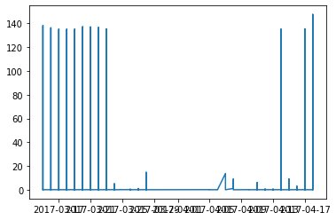

```python
plt.plot(df.date, df.duration)
```

#### Bytes and Packets

```
'c' argument looks like a single numeric RGB or RGBA sequence, which should be avoided as value-mapping will have precedence in case its length matches with 'x' & 'y'.  Please use a 2-D array with a single row if you really want to specify the same RGB or RGBA value for all points.
```

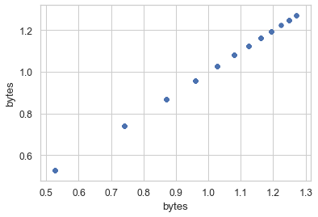

```python
#bivariate analysis saleprice/grlivarea
var = 'bytes'

data = pd.concat([X_train['bytes'], X_train[var]], axis=1)
data.plot.scatter(x=var, y='bytes');
```

```python
df.label.value_counts()
```

[output not shown]

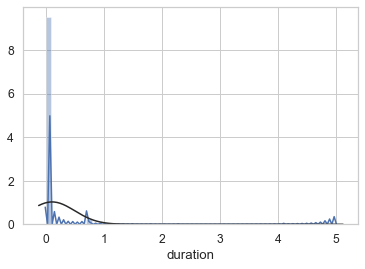

[figure not shown]

```python
#histogram and normal probability plot
sns.distplot(X_train['duration'], fit=norm);
fig = plt.figure()
#res = stats.probplot(X_train['duration'], plot=plt)
## IF I DO NOT USE THIS I WILL NEED TO REMOVE THE SETUP IMPORT OF Stats


## histogram and normal probability plot
# sns.distplot(df_train['SalePrice'], fit=norm);
# fig = plt.figure()
# res = stats.probplot(df_train['SalePrice'], plot=plt)
```

```python
# examine distributions of numerics dtype
df_num = df.select_dtypes(include = ['float64', 'int64'])
```

```
array([[<matplotlib.axes._subplots.AxesSubplot object at 0x1a203a6e50>,
      dtype=object)
```

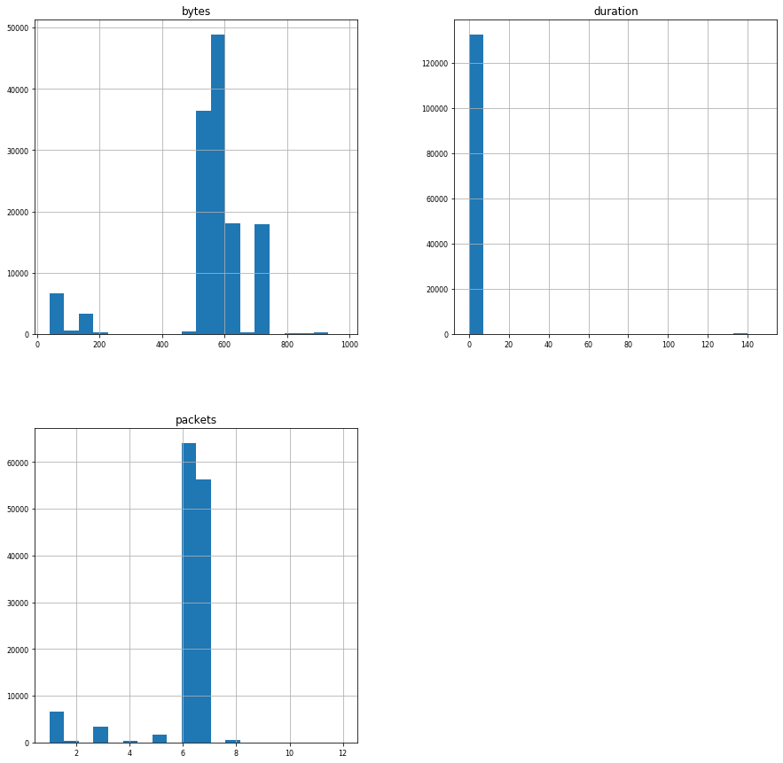

```python
# plot all numeric variables
df_num.hist(figsize=(15, 15), bins=20, xlabelsize=8, ylabelsize=8)
```

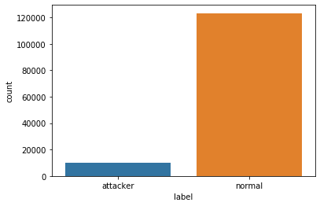

```python
sns.countplot(df['label']);
```

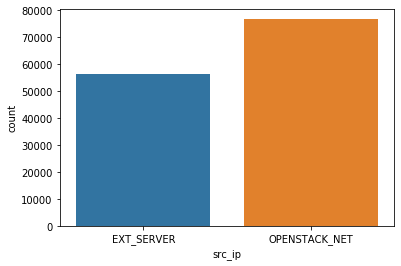

```python
sns.countplot(df['src_ip']);
```

```python
# # examine distributions of numerics dtype
# downsampled_cat = downsampled.select_dtypes(include = ['category'])

# fig, ax = plt.subplots(2, 2, figsize=(20, 10))
# for variable, subplot in zip(downsampled_cat, ax.flatten()):
#     sns.countplot(downsampled[variable], ax=subplot)
#     for label in subplot.get_xticklabels():
#         label.set_rotation(90)
```

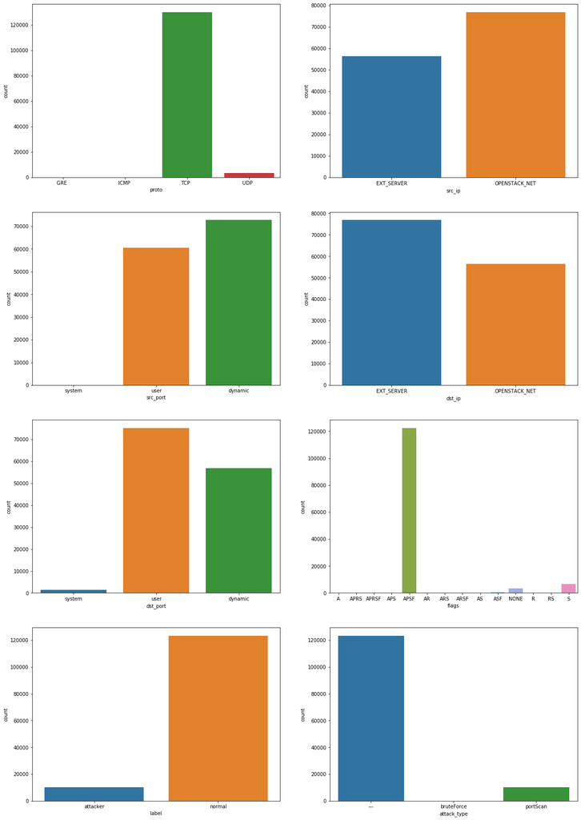

```python
# examine distributions of numerics dtype
df_cat = df.select_dtypes(include = ['category'])

fig, ax = plt.subplots(4, 2, figsize=(20, 30))
for variable, subplot in zip(df_cat, ax.flatten()):
    sns.countplot(df[variable], ax=subplot)
    for label in subplot.get_xticklabels():
        label.set_rotation(0)
```